# Angola Ocean Conservation Priorities

## Content

- Biodiversity
- Carbon
- Food provision
- Triple wins
- Equal weights

## Biodiversity

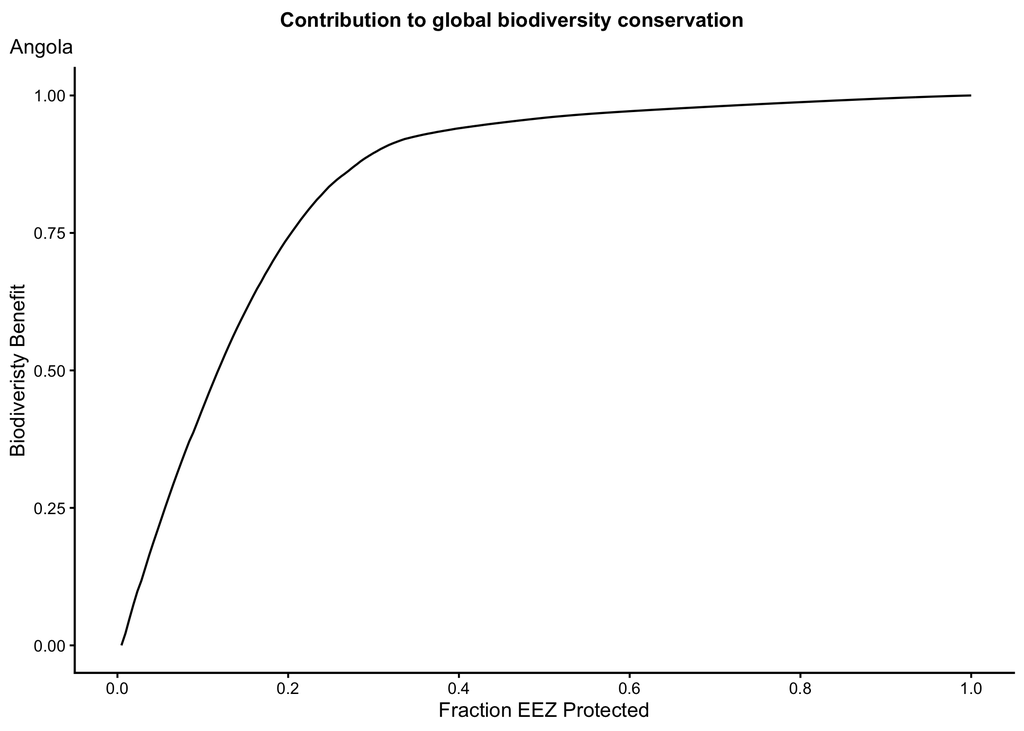

## Biodiversity

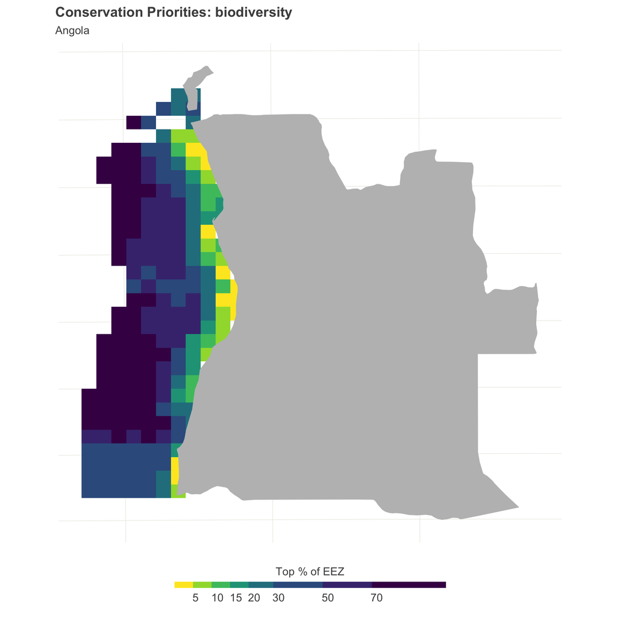

## Biodiversity

- The optimal strategy to maximize biodiversity benefits is to protect 100% of the EEZ.
- Protecting the optimal 10% of the EEZ would achieve 42 % of biodiversity benefits.
- Protecting the optimal 30% of the EEZ would achieve 89 % of biodiversity benefits

## Carbon

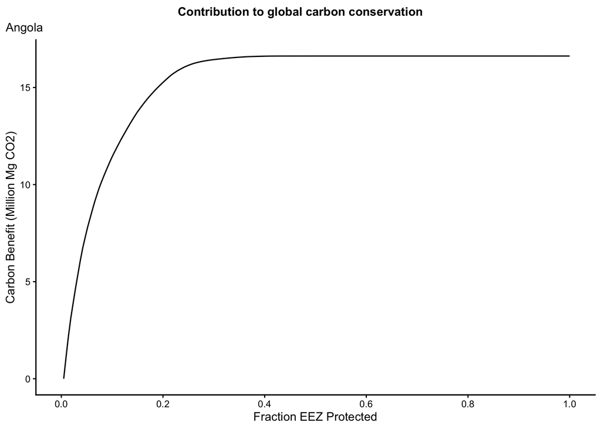

## Carbon

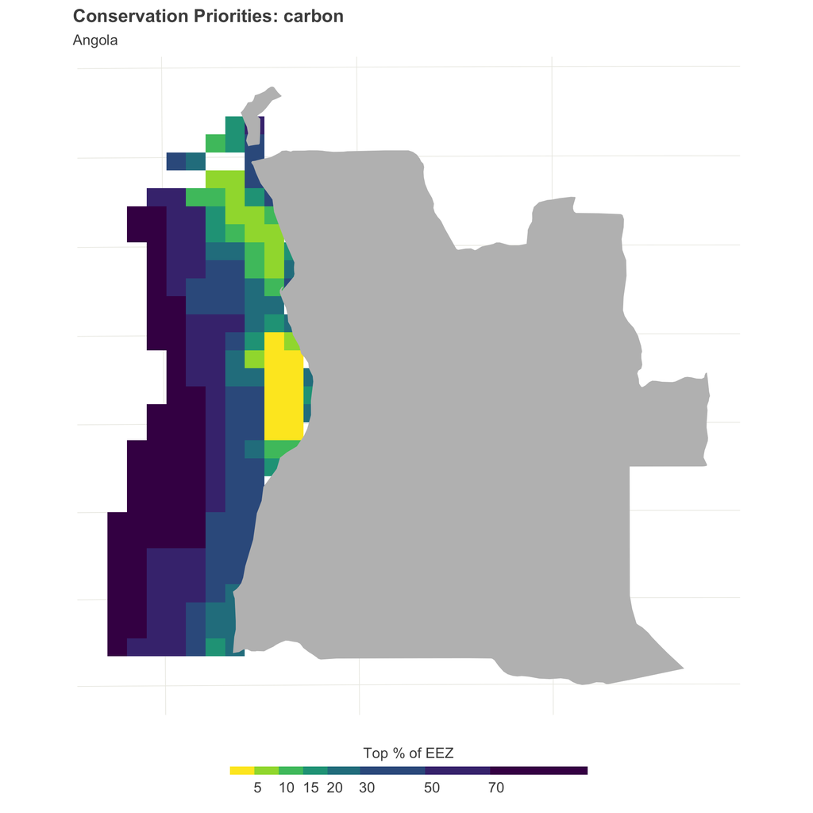

## Carbon

- The optimal strategy to maximize carbon benefits is to protect 51% of the EEZ. This would avoid the release of up to 17 million tons of CO2 as a result of bottom trawling.
- Protecting the optimal 10% of the EEZ would achieve 68 % of carbon benefits.
- Protecting the optimal 30% of the EEZ would achieve 99 % of carbon benefits

## Food

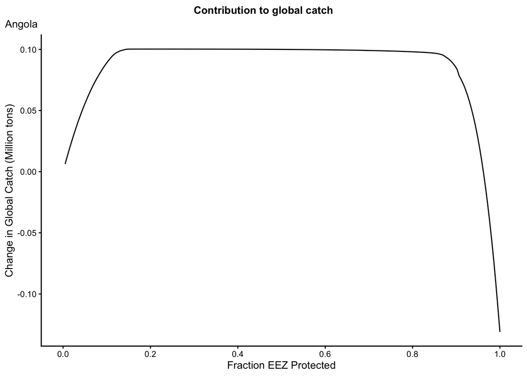

## Food

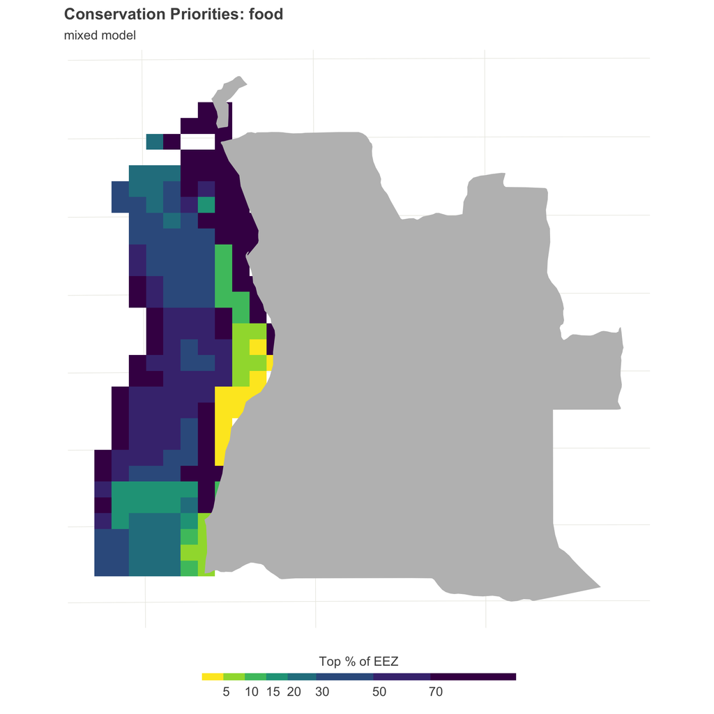

## Food

- The optimal strategy to maximize food provision benefits is to protect 22% of the EEZ. This would yield a net gain in catch of 100,249 tons
- Protecting the optimal 10% of the EEZ would achieve 95 % of food benefits.
- Protecting the optimal 30% of the EEZ would achieve 100 % of food benefits

## Triple wins

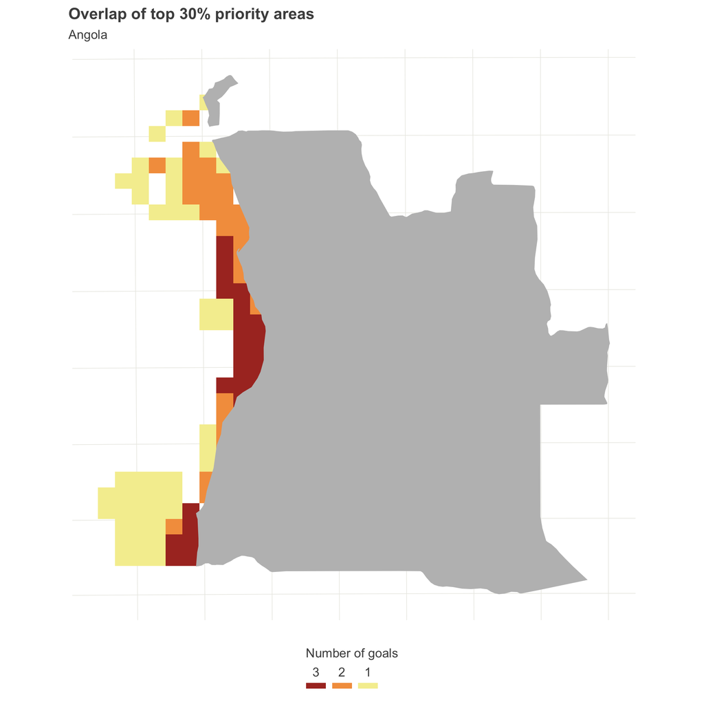

## Equal weights

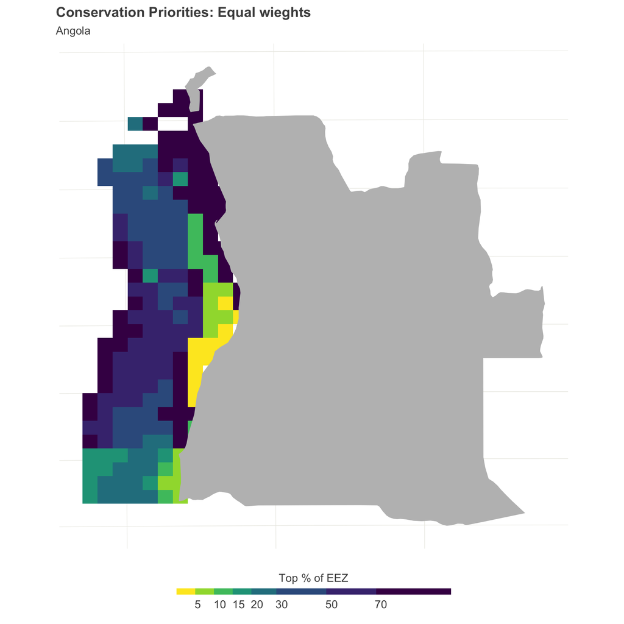

## Equal weights

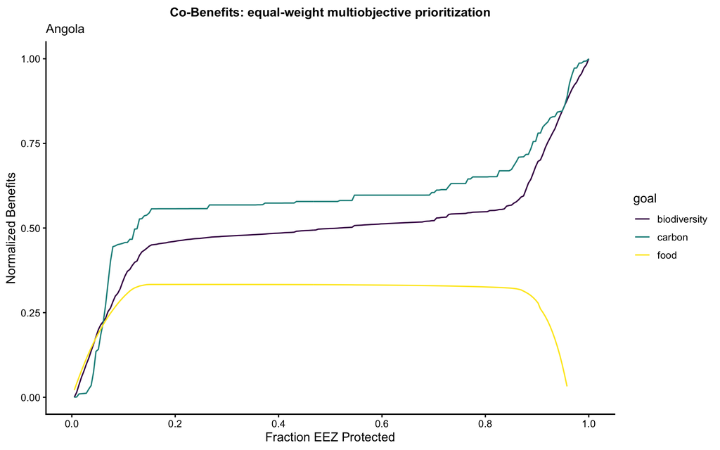

## Equal weights

- The optimal strategy to simultaneously maximize all objectives call for protection of 23 % of the EEZ.
- This would achieve 56 %, 47 %, 33 %, of the carbon, biodiversity, and food provision benefits, respectively.